# Séance 2.3: Exploration des données

Visseho Adjiwanou, PhD.

13 June 2021

# Enquête sociale générale, 1996

- Il s'agit du CROP Socio-Cultural Survey de 1996
- Dans cette partie, nous allons apprendre à :
  - Selectionner les **variables**
  - Sélectionner les observations
  - Réorganiser les données
  - Créer de nouvelles variables avec des fonctions de variables existantes (mutate ())
  - Recoder des variables existantes
  - Calculer des statistiques univariées

## Dressons la table

```r
# Effacer votre environnement

rm(list = ls())

# Installer les package dont vous avez besoin

#install.packages("tidyverse")
#install.packages("summarytools")
#install.packages("tinytex")

# Charger les packages - Étape fondamentales

library(tidyverse)
library(summarytools)
```

## Téléchargement de la base de données

```r
crsc96 <- read_csv("../Données/cora-crsc1996-E-1996_F1.csv")
```

## Sélectionnons les données qui nous intéressent

q1 : - I hate being bossed around: I must feel that I have total control over all the different areas of my life - **Je déteste être patronisé: je dois sentir que j'ai un contrôle total sur tous les différents domaines de ma vie**

q2: - An unmarried girl of 18 should not have sexual relations - *Une fille non mariée de 18 ans ne devrait pas avoir de relations sexuelles*

q3: - The best way to get something from someone is by putting your foot down - *La meilleure façon d'obtenir quelque chose de quelqu'un est de mettre le pied à terre (dialoguer)*

q4: - In a household where both partners are working, is not right for the wife to earn more than the husband - *Dans un ménage où les deux partenaires travaillent, il n'est pas normal que la femme gagne plus que le mari*

q44: - Overpopulation in third world countries doesn't really affect our country - *La surpopulation dans les pays du tiers monde n'affecte pas vraiment notre pays*

q95: - An extramarital affair from time to time is not that serious - *Une liaison extraconjugale de temps en temps n'est pas si grave*

q96: - I would like to have a religious service at my funeral - *J'aimerais avoir un service religieux à mes funérailles*

```r
crsc96_small <-
  crsc96 %>%
  select(sexq, region, age, ageq, q1, q2, q3, q4, q44, q95, q96)

crsc96_small
```

```
## # A tibble: 2,859 x 11
##     sexq region   age  ageq    q1    q2    q3    q4   q44   q95   q96
##    <dbl>  <dbl> <dbl> <dbl> <dbl> <dbl> <dbl> <dbl> <dbl> <dbl> <dbl>
##  1     2      9    33     3     1     5     5     5     4     5     1
##  2     2      9    34     3     2     5     4     5     5     5     5
##  3     2      9    56     4     2     2     4     5     5     4     5
##  4     1      9    69     5     1     4     2     4     5     5     2
##  5     1      9    43     3     4     4     4     5     5     4     4
##  6     2      9    28     2     4     5     4     5     5     5     2
##  7     1      9    27     2     2     4     2     4     4     5     4
##  8     1      9    51     4     1     4     4     5     5     4     2
##  9     1      9    41     3     1     5     5     5     4     4     5
## 10     1      9    39     3     4     2     5     5     4     5     1
## # … with 2,849 more rows
```

```r
crsc96_small <-
  crsc96_small %>%
  mutate(age4 = case_when(
    age < 20 ~ "adolescent",
    age >= 20 & age < 34 ~ "jeune",
    age >= 35 & age <59 ~ "adulte",
    age >=60 ~ "ainé"
  ))
```

# Statistiques univariées

## Statistiques univariées

Les objectifs de la statistique descriptive sont de : - définir le ou les groupes étudiées (population ou échantillon) - définir le codage des observations - définir la présentation des données : numérique et/ou graphique - réduire les données à quelques indicateurs statistiques synthétiques

# Distribution de fréquences et de pourcentage

## Utilisation de tidyverse

```r
nombre_sexe <-
  crsc96_small %>%
  count(sexe = sexq)

nombre_age4 <-
  crsc96_small %>%
  count(age = age4)
```

## Calculer des proportions

```r
proportion1 <-
  crsc96_small %>%
  count(sexe = sexq, age = age4) %>%
  mutate(proportion = n / (sum(n)))
proportion1
```

```
## # A tibble: 10 x 4
##     sexe age            n proportion
##    <dbl> <chr>      <int>      <dbl>
##  1     1 adolescent   137     0.0479
##  2     1 adulte       551     0.193
##  3     1 ainé         231     0.0808
##  4     1 jeune        386     0.135
##  5     1 <NA>          56     0.0196
##  6     2 adolescent   140     0.0490
##  7     2 adulte       617     0.216
##  8     2 ainé         295     0.103
##  9     2 jeune        394     0.138
## 10     2 <NA>          52     0.0182
```

```r
# proportion


proportion2 <-
  crsc96_small %>%
  group_by(sexq) %>%
  count(age = age4) %>%
  mutate(proportion = n / (sum(n)))
proportion2
```

```
## # A tibble: 10 x 4
## # Groups:   sexq [2]
##     sexq age            n proportion
##    <dbl> <chr>      <int>      <dbl>
##  1     1 adolescent   137     0.101
##  2     1 adulte       551     0.405
##  3     1 ainé         231     0.170
##  4     1 jeune        386     0.284
##  5     1 <NA>          56     0.0411
##  6     2 adolescent   140     0.0935
##  7     2 adulte       617     0.412
##  8     2 ainé         295     0.197
##  9     2 jeune        394     0.263
## 10     2 <NA>          52     0.0347
```

## Avec le package Summarytools

```r
freq(crsc96$sexq)
```

```
## Frequencies
## crsc96$sexq
## Type: Numeric
##
##               Freq   % Valid   % Valid Cum.   % Total   % Total Cum.
## ----------- ------ --------- -------------- --------- --------------
##           1   1361     47.60          47.60     47.60          47.60
##           2   1498     52.40         100.00     52.40         100.00
##        <NA>      0                               0.00         100.00
##       Total   2859    100.00         100.00    100.00         100.00
```

```r
freq(crsc96$q1)
```

```
## Frequencies
## crsc96$q1
## Type: Numeric
##
##               Freq   % Valid   % Valid Cum.   % Total   % Total Cum.
## ----------- ------ --------- -------------- --------- --------------
##           1   1065     37.25          37.25     37.25          37.25
##           2   1410     49.32          86.57     49.32          86.57
##           3      9      0.31          86.88      0.31          86.88
##           4    326     11.40          98.29     11.40          98.29
##           5     49      1.71         100.00      1.71         100.00
##        <NA>      0                               0.00         100.00
##       Total   2859    100.00         100.00    100.00         100.00
```

```r
freq(crsc96$region)
```

```
## Frequencies
## crsc96$region
## Type: Numeric
##
##               Freq   % Valid   % Valid Cum.   % Total   % Total Cum.
## ----------- ------ --------- -------------- --------- --------------
##           0    218      7.63           7.63      7.63           7.63
##           1    270      9.44          17.07      9.44          17.07
##           2    564     19.73          36.80     19.73          36.80
##           3    531     18.57          55.37     18.57          55.37
##           4    211      7.38          62.75      7.38          62.75
##           5    351     12.28          75.03     12.28          75.03
##           6    124      4.34          79.36      4.34          79.36
##           7    117      4.09          83.46      4.09          83.46
##           8    240      8.39          91.85      8.39          91.85
##           9    233      8.15         100.00      8.15         100.00
##        <NA>      0                               0.00         100.00
##       Total   2859    100.00         100.00    100.00         100.00
```

```r
freq(crsc96$q44)
```

```
## Frequencies
## crsc96$q44
## Type: Numeric
##
##               Freq   % Valid   % Valid Cum.   % Total   % Total Cum.
## ----------- ------ --------- -------------- --------- --------------
##           1    118      4.13           4.13      4.13           4.13
##           2    414     14.48          18.61     14.48          18.61
##           3     18      0.63          19.24      0.63          19.24
##           4   1293     45.23          64.46     45.23          64.46
##           5   1016     35.54         100.00     35.54         100.00
##        <NA>      0                               0.00         100.00
##       Total   2859    100.00         100.00    100.00         100.00
```

```r
freq(crsc96$q95)
```

```
## Frequencies
## crsc96$q95
## Type: Numeric
##
##               Freq   % Valid   % Valid Cum.   % Total   % Total Cum.
## ----------- ------ --------- -------------- --------- --------------
##           1     66      2.31           2.31      2.31           2.31
##           2    240      8.39          10.70      8.39          10.70
##           3     22      0.77          11.47      0.77          11.47
##           4    605     21.16          32.63     21.16          32.63
##           5   1926     67.37         100.00     67.37         100.00
##        <NA>      0                               0.00         100.00
##       Total   2859    100.00         100.00    100.00         100.00
```

# Paramètres de tendances centrales et de dispersion

## Avec base R

La commande summary nous donne une premieère indication sur l'ensemble des variables de notre base de données. Il faut préter attention aux variables manquantes.

```r
summary(crsc96_small)
```

```
##       sexq           region           age             ageq             q1
##  Min.   :1.000   Min.   :0.000   Min.   :15.00   Min.   :1.000   Min.   :1.00
##  1st Qu.:1.000   1st Qu.:2.000   1st Qu.:28.00   1st Qu.:2.000   1st Qu.:1.00
##  Median :2.000   Median :3.000   Median :39.00   Median :3.000   Median :2.00
##  Mean   :1.524   Mean   :3.907   Mean   :41.45   Mean   :3.226   Mean   :1.91
##  3rd Qu.:2.000   3rd Qu.:5.000   3rd Qu.:54.00   3rd Qu.:4.000   3rd Qu.:2.00
##  Max.   :2.000   Max.   :9.000   Max.   :99.00   Max.   :5.000   Max.   :5.00
##        q2             q3              q4             q44             q95
##  Min.   :1.00   Min.   :1.000   Min.   :1.000   Min.   :1.000   Min.   :1.000
##  1st Qu.:2.00   1st Qu.:2.000   1st Qu.:4.000   1st Qu.:4.000   1st Qu.:4.000
##  Median :4.00   Median :4.000   Median :5.000   Median :4.000   Median :5.000
##  Mean   :3.28   Mean   :3.685   Mean   :4.524   Mean   :3.936   Mean   :4.429
##  3rd Qu.:5.00   3rd Qu.:5.000   3rd Qu.:5.000   3rd Qu.:5.000   3rd Qu.:5.000
##  Max.   :5.00   Max.   :5.000   Max.   :5.000   Max.   :5.000   Max.   :5.000
##       q96          age4
##  Min.   :1.0   Length:2859
##  1st Qu.:1.0   Class :character
##  Median :2.0   Mode  :character
##  Mean   :2.3
##  3rd Qu.:4.0
##  Max.   :5.0
```

L’inconvénient, c'est que c'est mal présenté, et ce ne sont pas l'ensemble des variables de notre base de données qui nous concernent. Les informations sur les variables nominales ne sont pas fournis.

## Paramètres de position (Base R)

```r
age_moyen <- mean(crsc96_small$age)
age_moyen
```

```
## [1] 41.45261
```

```r
age_mediane <- median(crsc96_small$age)
age_mediane
```

```
## [1] 39
```

Cette approche n'est pas la bonne car elle nous demande beaucoup de coding (avec la création de plusieurs objets)

## Paramètres de position - tidyverse

La fonction `summarise` permet de calculer l'ensemble des indicateurs dont nous avons besoin. Dans toute étude, il est important de résumé l'information contenue dans les variables pour se faire une première idée.

```r
age_position <-
  crsc96_small %>%
  summarise(age_moyen = mean(age),
            age_median = median(age),
            age_Q1 = quantile(age, prob = 0.25),
            age_Q3 = quantile(age, prob = 0.75),
            age_min = min(age))
age_position
```

```
## # A tibble: 1 x 5
##   age_moyen age_median age_Q1 age_Q3 age_min
##       <dbl>      <dbl>  <dbl>  <dbl>   <dbl>
## 1      41.5         39     28     54      15
```

## Statistiques univariées: Mode

Il n'y a aucune fonction qui permet de calculer directement le mode. Alors, il faut la créer soi-même.

```r
getmode <- function(v) {
   uniqv <- unique(v)
   uniqv[which.max(tabulate(match(v, uniqv)))]
}


age_position <-
  crsc96_small %>%
  summarise(age_moyen = mean(age),
            age_median = median(age),
            age_Q1 = quantile(age, prob = 0.25),
            age_Q1 = quantile(age, prob = 0.75),
            age_mode = getmode(age))

age_position
```

```
## # A tibble: 1 x 4
##   age_moyen age_median age_Q1 age_mode
##       <dbl>      <dbl>  <dbl>    <dbl>
## 1      41.5         39     54       29
```

## Statistiques univariées : Histogramme

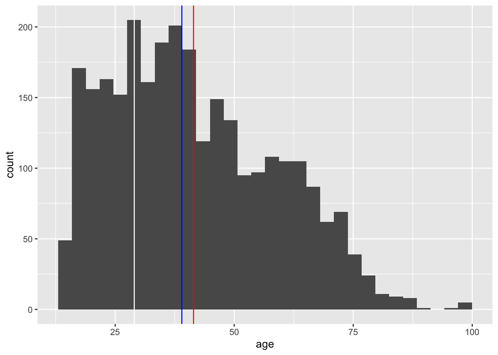

```r
ggplot(crsc96_small) +
  geom_histogram(aes(x = age)) +
  geom_vline(aes(xintercept = mean(age)), color = "red") +
  geom_vline(aes(xintercept = median(age)), color = "blue") +
  geom_vline(aes(xintercept = getmode(age)), color = "white")
```

On reviendra sur le cours prochain sur la visualisation, l'une des forces de tidyverse.

## Statistique par groupe

Nous pouvons aussi regarder ces données selon le sexe des individus

```r
age_position_sexe <-
  crsc96_small %>%
  group_by(sexq) %>%
  summarise(age_moyen = mean(age),
            age_median = median(age),
            age_Q1 = quantile(age, prob = 0.25),
            age_Q3 = quantile(age, prob = 0.75),
            age_mode = getmode(age))

age_position_sexe
```

```
## # A tibble: 2 x 6
##    sexq age_moyen age_median age_Q1 age_Q3 age_mode
##   <dbl>     <dbl>      <dbl>  <dbl>  <dbl>    <dbl>
## 1     1      40.8         39     27     52       44
## 2     2      42.0         40     28     55       38
```

```r
age_position_sexe <-
  age_position_sexe %>%
  mutate(écart = age_moyen - age_median)


age_position_age4 <-
  crsc96_small %>%
  group_by(age4) %>%
  summarise(age_moyen = mean(age),
            age_median = median(age),
            age_Q1 = quantile(age, prob = 0.25),
            age_Q1 = quantile(age, prob = 0.75),
            age_mode = getmode(age))

age_position_age4
```

```
## # A tibble: 5 x 5
##   age4       age_moyen age_median age_Q1 age_mode
##   <chr>          <dbl>      <dbl>  <dbl>    <dbl>
## 1 adolescent      17.1         17     18       18
## 2 adulte          44.7         44     50       38
## 3 ainé            68.5         67     72       60
## 4 jeune           26.7         27     30       29
## 5 <NA>            44.0         34     59       34
```

## Statistiques univariés sur plusieurs variables, solution alternative

On regarde les statistiques pas sur une seule variable mais sur plusieurs variables. On peut combiner plusieurs tableaux avec les fonctions `binds_row` et `binds_col`.

```r
position_q <-
  crsc96_small %>%
  select(num_range("q", c(1:4, 44, 95))) %>%
  summarise_each(funs(mean, median))
position_q
```

```
## # A tibble: 1 x 12
##   q1_mean q2_mean q3_mean q4_mean q44_mean q95_mean q1_median q2_median
##     <dbl>   <dbl>   <dbl>   <dbl>    <dbl>    <dbl>     <dbl>     <dbl>
## 1    1.91    3.28    3.68    4.52     3.94     4.43         2         4
## # … with 4 more variables: q3_median <dbl>, q4_median <dbl>, q44_median <dbl>,
## #   q95_median <dbl>
```

Le problème, c'est la longueur du fichier.

## EXERCICE

Calculer les paramètres de dispersion de la variable age et commenter.

## Application 1: Données abbérantes ou extrêmes

```r
#install.packages("carData")
library(carData)
library(tidyverse)
data(package = "carData")

data("Davis", package = "carData")
save(Davis, file = "Davis.Rdata")


load(file = "Davis.Rdata")

summary(Davis)
```

```
##  sex         weight          height          repwt            repht
##  F:112   Min.   : 39.0   Min.   : 57.0   Min.   : 41.00   Min.   :148.0
##  M: 88   1st Qu.: 55.0   1st Qu.:164.0   1st Qu.: 55.00   1st Qu.:160.5
##          Median : 63.0   Median :169.5   Median : 63.00   Median :168.0
##          Mean   : 65.8   Mean   :170.0   Mean   : 65.62   Mean   :168.5
##          3rd Qu.: 74.0   3rd Qu.:177.2   3rd Qu.: 73.50   3rd Qu.:175.0
##          Max.   :166.0   Max.   :197.0   Max.   :124.00   Max.   :200.0
##                                          NA's   :17       NA's   :17
```

Ce fichier comprend les informations sur le poids et la taille de 200 individues ainsi que leur poids et taille autodéclaré. On veut voir de quelle manière les poids auto-déclarés sont fiables.

On ne l'a pas encore vu, mais on peut rapidement voir les variables deux par deux dans un graphique

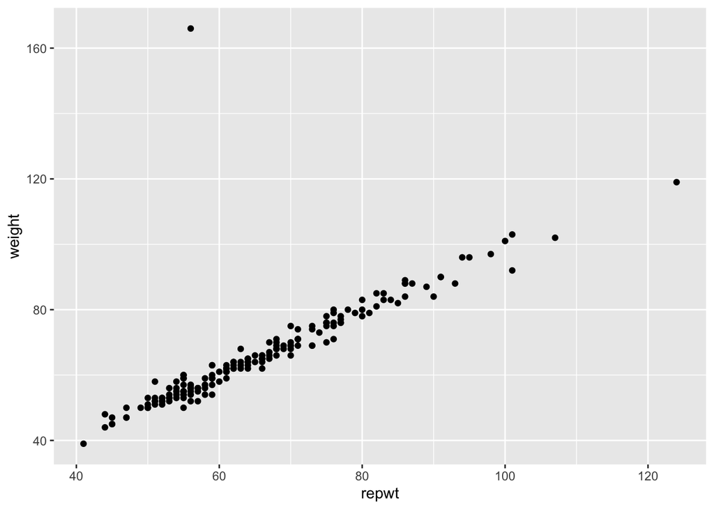

```r
ggplot(Davis) +
  geom_point(aes(x = repwt, y = weight))
```

## Application 2 : Données manquantes

```r
poids_moyen <-
  Davis %>%
  summarise(poids_moyen = mean(weight))
poids_moyen
```

```
##   poids_moyen
## 1        65.8
```

```r
poids_moyen_reporte <-
  Davis %>%
  summarise(poids_moyen_reporte = mean(repwt))
poids_moyen_reporte
```

```
##   poids_moyen_reporte
## 1                  NA
```

Qu'est-ce qui s'est passé. En fait, le poids reporté comporte des valeurs manquantes. Il faut indiquer dans le calcul de la moyenne qu'il y a des valeurs manquantes, et qu'il faut les enlever avant de calculer la moyenne, ou toute autre statistique.

```r
poids_moyen_reporte <-
  Davis %>%
  summarise(poids_moyen_reporte = mean(repwt, na.rm = TRUE))
poids_moyen_reporte
```

```
##   poids_moyen_reporte
## 1            65.62295
```

Quel est le problème qui se pose quand des informations sont manquantes. Peut-on faire confiance aux résultats?

## Remarques

1. Tous les objets que vous créez, vous pouvez les manipuler à votre guise
2. Les variables que vous créez, vous pouvez les réutiliser juste après
3. Interprétations des résultats

# Statistiques bivariées : Association entre variables

## Statistiques bivariées : Association entre variables

Existe-il une relation entre l'age et l'opinion des gens? Existe-il une relation entre le sexe et l'opinion des gens?

```r
crsc96_small <-
  crsc96_small %>%
  mutate(sexe = factor(sexq, labels = c("Homme", "Femme")))

freq(crsc96_small$sexe)
```

```
## Frequencies
## crsc96_small$sexe
## Type: Factor
##
##               Freq   % Valid   % Valid Cum.   % Total   % Total Cum.
## ----------- ------ --------- -------------- --------- --------------
##       Homme   1361     47.60          47.60     47.60          47.60
##       Femme   1498     52.40         100.00     52.40         100.00
##        <NA>      0                               0.00         100.00
##       Total   2859    100.00         100.00    100.00         100.00
```

## Association

- Sexe avec la variable q2

q2: "An unmarried girl of 18 should not have sexual relations" Une jeune fille non mariée de 18 ans ne devrait pas avoir de relations sexuelles - Se fait à base de tableaux croisés (contingency table)

```r
qlabel <- c("totally agree", "agree somewhat", "DK/NA", "disagree somewhat", "totally disagree")

crsc96_small <-
  crsc96_small %>%
  mutate(q2_new = factor(q2, labels = qlabel),
         q3_new = factor(q3, labels = qlabel))

ctable(crsc96_small$sexe, crsc96_small$q2_new)
```

```
## Cross-Tabulation, Row Proportions
## sexe * q2_new
## Data Frame: crsc96_small
##
## ------- -------- --------------- ---------------- ----------- ------------------- ------------------ ---------------
##           q2_new   totally agree   agree somewhat       DK/NA   disagree somewhat   totally disagree           Total
##    sexe
##   Homme              208 (15.3%)      304 (22.3%)   12 (0.9%)         418 (30.7%)        419 (30.8%)   1361 (100.0%)
##   Femme              308 (20.6%)      332 (22.2%)   14 (0.9%)         476 (31.8%)        368 (24.6%)   1498 (100.0%)
##   Total              516 (18.0%)      636 (22.2%)   26 (0.9%)         894 (31.3%)        787 (27.5%)   2859 (100.0%)
## ------- -------- --------------- ---------------- ----------- ------------------- ------------------ ---------------
```

## Association

Les colonnes et les lignes d'un tableau croisés, ne sont pas identiques.

```r
ctable(crsc96_small$q2_new, crsc96_small$sexe)
```

```
## Cross-Tabulation, Row Proportions
## q2_new * sexe
## Data Frame: crsc96_small
##
## ------------------- ------ -------------- -------------- ---------------
##                       sexe          Homme          Femme           Total
##              q2_new
##       totally agree           208 (40.3%)    308 (59.7%)    516 (100.0%)
##      agree somewhat           304 (47.8%)    332 (52.2%)    636 (100.0%)
##               DK/NA            12 (46.2%)     14 (53.8%)     26 (100.0%)
##   disagree somewhat           418 (46.8%)    476 (53.2%)    894 (100.0%)
##    totally disagree           419 (53.2%)    368 (46.8%)    787 (100.0%)
##               Total          1361 (47.6%)   1498 (52.4%)   2859 (100.0%)
## ------------------- ------ -------------- -------------- ---------------
```

Lequel des deux tableaux donne une indication sur l'association entre les deux variables?

## Association

Aussi, est-il important de préciser si vous calculer des proportions lignes ou des proportions colonnes.

```r
ctable(crsc96_small$sexe, crsc96_small$q2_new, "r")
```

```
## Cross-Tabulation, Row Proportions
## sexe * q2_new
## Data Frame: crsc96_small
##
## ------- -------- --------------- ---------------- ----------- ------------------- ------------------ ---------------
##           q2_new   totally agree   agree somewhat       DK/NA   disagree somewhat   totally disagree           Total
##    sexe
##   Homme              208 (15.3%)      304 (22.3%)   12 (0.9%)         418 (30.7%)        419 (30.8%)   1361 (100.0%)
##   Femme              308 (20.6%)      332 (22.2%)   14 (0.9%)         476 (31.8%)        368 (24.6%)   1498 (100.0%)
##   Total              516 (18.0%)      636 (22.2%)   26 (0.9%)         894 (31.3%)        787 (27.5%)   2859 (100.0%)
## ------- -------- --------------- ---------------- ----------- ------------------- ------------------ ---------------
```

```r
ctable(crsc96_small$sexe, crsc96_small$q2_new, "c")
```

```
## Cross-Tabulation, Column Proportions
## sexe * q2_new
## Data Frame: crsc96_small
##
## ------- -------- --------------- ---------------- ------------- ------------------- ------------------ ---------------
##           q2_new   totally agree   agree somewhat         DK/NA   disagree somewhat   totally disagree           Total
##    sexe
##   Homme             208 ( 40.3%)     304 ( 47.8%)   12 ( 46.2%)        418 ( 46.8%)       419 ( 53.2%)   1361 ( 47.6%)
##   Femme             308 ( 59.7%)     332 ( 52.2%)   14 ( 53.8%)        476 ( 53.2%)       368 ( 46.8%)   1498 ( 52.4%)
##   Total             516 (100.0%)     636 (100.0%)   26 (100.0%)        894 (100.0%)       787 (100.0%)   2859 (100.0%)
## ------- -------- --------------- ---------------- ------------- ------------------- ------------------ ---------------
```

## Questions

Que faites vous si une des variables est quantitative, par exemple l’âge et q2_new